**Package: MetaGSCA 0.1.0**

# 1 Introduction

This vignette provides an overview of the Bioconductor package for differential co-expression p-value.

**MetaGSCA (Meta Gene Set Co-expression Analysis)** is a computational tool to systematically assess the co-expression disturbance of a specified gene set with rigorous meta-analysis justification. A nonparametric approach that accounts for the correlation structure between genes is used to test whether the gene set is differentially co-expresssed between the two conditions, and a **permutation test p-value** is computed. **Bootstrapping** is used to construct confidence intervals of point estimates. A **meta-analysis of single proportions** is then performed with two options: random-intercept logistic regression model and the inverse variance method, to yield conclusive results over a number of individual studies. The meta-analysis empowered gene set differential co-expression tool MetaGSCA is implemented in the form of both a web application and an R package.

Packages **data.table, meta(metafor), grid, sjstats, igraph** are required.

The analysis will start by loading package MetaGSCA.

```r
library(MetaGSCA)
```

# 2 How to use the MetaGSCA package

This Section illustrates the typical procedure for applying the methods available in package **MetaGSCA**.

## 2.1 Set Working Directory

Create a temporary directory “workdir” under the user’s current working directory. All output generated in this vignette will be saved in “workdir”.

```r
## set your workdir
workdir <- setwd()
```

## 2.2 Example Data

Load the example data:  
**1. lists of genesets (29 pathways)**  
**2. lists of datasets (KIRP & LIHC)**  
The 2 sourse of data are necessary for running the examples and case studies in this vignette.

```r
###########################
## step 1, read in pathways
mygeneset <- list.files(system.file("data", package = "MetaGSCA"),
                        pattern = "*.lst", full.names=TRUE)
genesets <- list(); genesetnames <- list()
for (i in 1:length(mygeneset)) {
    g <- fread(mygeneset[i], header = FALSE, data.table = FALSE)
    genesets[[i]] <- as.character(g[, 1])
    genesetnames[[i]] <- tools::file_path_sans_ext(mygeneset[i])
}
genesetnames <- gsub(paste(system.file("data", package = "MetaGSCA"),
                     "/", sep = ""), "", genesetnames)

##########################
## step 2,read in datasets
mydataset <- c(paste(system.file("data", package = "MetaGSCA"),
                     "/KIRP.csv", sep=""),
               paste(system.file("data", package = "MetaGSCA"),
                     "/LIHC.csv", sep=""))
datasets <- list(); groups <- list(); datasetnames <- list()
for (j in 1:length(mydataset)) {
    d <- fread(mydataset[j], header = TRUE, data.table = FALSE)
    datasets[[j]] <- d[-1,]
    groups[[j]] <- as.character(d[1, -1])
    datasetnames[[j]] <- tools::file_path_sans_ext(mydataset[j])
}
datasetnames <- gsub(paste(system.file("data", package = "MetaGSCA"),
                     "/", sep = ""), "", datasetnames)
```

**Note:**  
**1. lists of genesets (29 pathways):**

```
##  [1] "Alanine,Aspartic acid and Asparagine metabolism"
##  [2] "Aminosugars metabolism"
##  [3] "Arginine and Proline metabolism"
##  [4] "Butanoate metabolism"
##  [5] "Folate metabolism"
##  [6] "Fructose and Mannose metabolism"
##  [7] "Fructose galactose metabolism"
##  [8] "Galactose metabolism"
##  [9] "Glutamic acid and Glutamine metabolism"
## [10] "Glycine and Serine metabolism"
## [11] "GPCR GroupI metabotropic glutamate receptor signaling pathway"
## [12] "Inositol phosphate metabolism"
## [13] "Mannose metabolism"
## [14] "Metabotropic glutamate receptor group I pathway"
## [15] "Metabotropic glutamate receptor group II pathway"
## [16] "Metabotropic glutamate receptor group III pathway"
## [17] "Methionine and Cysteine metabolism"
## [18] "N-acetylglucosamine metabolism"
## [19] "Nicotinate and Nicotinamide metabolism"
## [20] "Porphyrin metabolism"
## [21] "Propanoate metabolism"
## [22] "Prostaglandin and Leukotriene metabolism"
## [23] "Purine nucleotides and Nucleosides metabolism"
## [24] "Pyrimidine Metabolism"
## [25] "Pyrimidine Nucleotides and Nucleosides metabolism"
## [26] "Pyruvate metabolism"
## [27] "Steroids metabolism"
## [28] "Tyrosine metabolism"
## [29] "Vitamin D metabolism and pathway"
```

## 2.3 Case Study

### 2.3.1 Example 1: MetaGSCA

#### 2.3.1.1 Code

**MetaGSCA** is used to perform meta & gene set co-expression analysis of one geneset.

**Arguments**  
* *list.geneset:* **a** pre-specified gene list from a gene set or pathway.  
* *list.dataset:* a list of datasets, first column is gene name.  
* *list.group:* a list of samples/patients subgroup or condition (e.g. (1,1,1,2,2,2)).  
* *name.geneset:* the name of the gene set, used for output file name.  
* *name.dataset:* a list of dataset names corresponding to list.dataset, used for forest plot.  
* *nperm:* number of permutations used to estimate the null distribution of the test statistic. If not given, a default value 500 is used.  
* *nboot:* number of bootstraps used to estimate the point and interval estimate. If not given, a default value 200 is used.  
* *method.Inverse:* logical. Indicating whether “Inverse” method is to be used for pooling of studies.  
* *method.GLMM:* logical. Indicating whether “GLMM” method is to be used for pooling of studies.  
* *fixed.effect:* logical. Indicating whether a fixed effect meta-analysis should be conducted.  
* *random.effect:* logical. Indicating whether a random effects meta-analysis should be conducted.

```r
## step 3.1,call MetaGSCA function to perform Meta-analysis
# dir.create(file.path(workdir, "result_single_geneset"), showWarnings = FALSE)
# setwd(file.path(workdir, "result_single_geneset"))
MetaGSCA(list.geneset = genesets[[2]],
         list.dataset = datasets,
         list.group = groups,
         name.geneset = genesetnames[[2]],
         name.dataset = datasetnames,
         nperm = 100,
         nboot = 100,
         method.Inverse = FALSE,
         method.GLMM = TRUE,
         fixed.effect = FALSE,
         random.effect = TRUE)
```

#### 2.3.1.2 Result

```r
genesetnames[2]
```

```
## [1] "Aminosugars metabolism"
```

```r
genesets[2]
```

```
## [[1]]
##  [1] "CMAS"    "GCK"     "GFPT1"   "GFPT2"   "GNE"     "GNPDA1"  "GNPNAT1"
##  [8] "HK1"     "HK2"     "HK3"     "MPI"     "NAGK"    "NANS"    "PGM3"
## [15] "RENBP"   "UAP1"
```

There’ll be 2 output file after **MetaGSCA**. 1 forest plot (.pdf) and 1 output data information file (.csv).

[figure not shown]

In the first file, we’re able to get the forest plot of 2 datasets (KIRP & LIHC), with random effects model result. Attached with bootstrap result at the bottom side.

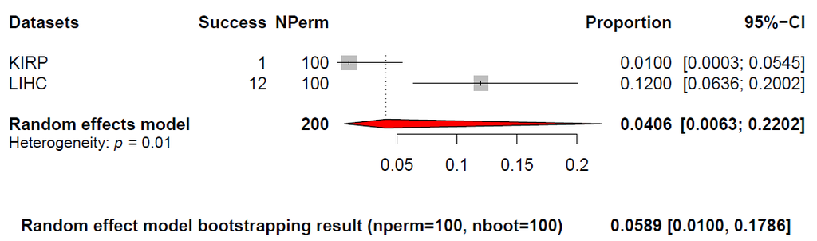

Gene[2]: Aminosugars metabolism_GLMM_Meta Analysis for bootstrap p-value_Forest plot

In the second file, it includes the output data information of 2 datasets (KIRP & LIHC).

Gene[2]: Aminosugars metabolism_Individual Dataset GSAR Results with Bootstrapping

```
##                         [,1]
## X                       "KIRP"
## Original.TS             "7.476495"
## Original.Pvalue         "0.009901"
## Boot.TS.Mean            "6.386472"
## Boot.TS.Bias            "-1.090023"
## Boot.TS.Std             "0.924679"
## Boot.TS.Norm.CI         "95% CI: [4.574134, 8.19881]"
## Boot.TS.PT.CI           "95% CI: [4.602247, 8.116174]"
## Boot.Pvalue.Mean        "0.012079"
## Boot.Pvalue.Bias        "0.002178"
## Boot.Pvalue.Std         "0.010008"
## Boot.Pvalue.Norm.CI     "95% CI: [-0.007537, 0.031695]"
## Boot.Pvalue.PT.CI       "95% CI: [0.009901, 0.029703]"
## Genes.not.found         "-"
## Genes.removed.sd.0.001. "-"
##                         [,2]
## X                       "LIHC"
## Original.TS             "3.845594"
## Original.Pvalue         "0.118812"
## Boot.TS.Mean            "3.870066"
## Boot.TS.Bias            " 0.024472"
## Boot.TS.Std             "0.642250"
## Boot.TS.Norm.CI         "95% CI: [2.611279, 5.128854]"
## Boot.TS.PT.CI           "95% CI: [2.806858, 5.144551]"
## Boot.Pvalue.Mean        "0.246832"
## Boot.Pvalue.Bias        "0.128020"
## Boot.Pvalue.Std         "0.217800"
## Boot.Pvalue.Norm.CI     "95% CI: [-0.180049, 0.673712]"
## Boot.Pvalue.PT.CI       "95% CI: [0.009901, 0.758168]"
## Genes.not.found         "-"
## Genes.removed.sd.0.001. "-"
```

### 2.3.2 Example 2: MetaGSCA_Multi_Geneset

#### 2.3.2.1 Code

**MetaGSCA_Multi_Geneset** is used to perform meta & gene set co-expression analysis of multiple geneset.

**Arguments**  
* *list.geneset:* **several** pre-specified gene lists from a gene set or pathway.  
* *name.geneset:* the names of the gene sets, used for output file name.

```r
## step 3.2,call MetaGSCA_Multi_Geneset function to perform Multiple geneset Meta-analysis
# dir.create(file.path(workdir, "result_multiple_geneset"), showWarnings = FALSE)
# setwd(file.path(workdir, "result_multiple_geneset"))
MetaGSCA_Multi_Geneset(list.geneset = genesets[2:3],
                       list.dataset = datasets,
                       list.group = groups,
                       name.geneset = genesetnames[2:3],
                       name.dataset = datasetnames,
                       nperm = 100,
                       nboot = 100,
                       method.Inverse = FALSE,
                       method.GLMM = TRUE,
                       fixed.effect = FALSE,
                       random.effect = TRUE)
```

#### 2.3.2.2 Result

```r
genesetnames[2:3]
```

```
## [1] "Aminosugars metabolism"          "Arginine and Proline metabolism"
```

```r
genesets[2:3]
```

```
## [[1]]
##  [1] "CMAS"    "GCK"     "GFPT1"   "GFPT2"   "GNE"     "GNPDA1"  "GNPNAT1"
##  [8] "HK1"     "HK2"     "HK3"     "MPI"     "NAGK"    "NANS"    "PGM3"
## [15] "RENBP"   "UAP1"
##
## [[2]]
##  [1] "ABAT"    "ALDH1A1" "ALDH1B1" "ALDH2"   "ALDH3A2" "ALDH4A1" "ALDH7A1"
##  [8] "ALDH9A1" "AMD1"    "AOC1"    "AOC2"    "AOC3"    "ARG1"    "ARG2"
## [15] "ASL"     "ASS1"    "CKB"     "CKM"     "CKMT1A"  "CKMT1B"  "CKMT2"
## [22] "EPRS"    "FH"      "GAMT"    "GATM"    "GLUD1"   "GLUD2"   "GLUL"
## [29] "GOT1"    "GOT2"    "MAOA"    "MAOB"    "NOS1"    "NOS2"    "NOS3"
## [36] "OAT"     "ODC1"    "OTC"     "P4HA1"   "P4HA2"   "PYCR1"   "PYCR3"
## [43] "RARS"    "SAT1"    "SDHA"    "SDHB"    "SMS"     "SRM"
```

There’ll be 4 output file after **MetaGSCA**. 2 forest plot (.pdf) and 2 output data information file (.csv).

[figure not shown]

In the 2 forest plot files, we’re able to get the forest plot of 2 datasets (KIRP & LIHC), with random effects model result. Attached with bootstrap result at the bottom side.

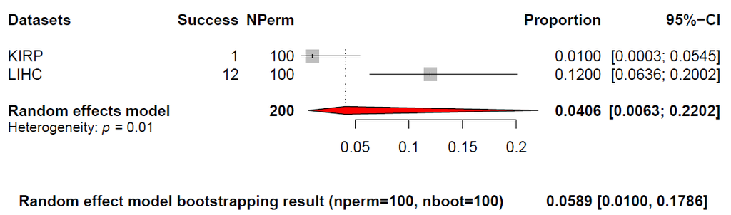

Gene[2]: Aminosugars metabolism_GLMM_Meta Analysis for bootstrap p-value_Forest plot

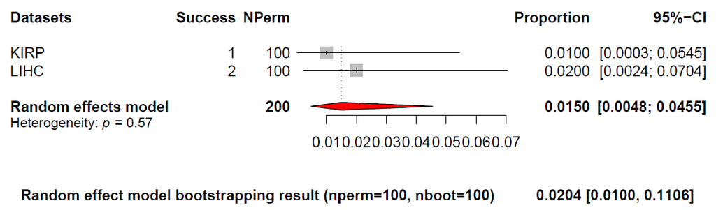

Gene[3]: Arginine and Proline metabolism_GLMM_Meta Analysis for bootstrap p-value_Forest plot

In the 2 output data information files, they includes the output data information of 2 datasets (KIRP & LIHC).

Gene[2]: Aminosugars metabolism_Individual Dataset GSAR Results with Bootstrapping

```
##                         [,1]
## X                       "KIRP"
## Original.TS             "7.476495"
## Original.Pvalue         "0.009901"
## Boot.TS.Mean            "6.386472"
## Boot.TS.Bias            "-1.090023"
## Boot.TS.Std             "0.924679"
## Boot.TS.Norm.CI         "95% CI: [4.574134, 8.19881]"
## Boot.TS.PT.CI           "95% CI: [4.602247, 8.116174]"
## Boot.Pvalue.Mean        "0.012079"
## Boot.Pvalue.Bias        "0.002178"
## Boot.Pvalue.Std         "0.010008"
## Boot.Pvalue.Norm.CI     "95% CI: [-0.007537, 0.031695]"
## Boot.Pvalue.PT.CI       "95% CI: [0.009901, 0.029703]"
## Genes.not.found         "-"
## Genes.removed.sd.0.001. "-"
##                         [,2]
## X                       "LIHC"
## Original.TS             "3.845594"
## Original.Pvalue         "0.118812"
## Boot.TS.Mean            "3.870066"
## Boot.TS.Bias            " 0.024472"
## Boot.TS.Std             "0.642250"
## Boot.TS.Norm.CI         "95% CI: [2.611279, 5.128854]"
## Boot.TS.PT.CI           "95% CI: [2.806858, 5.144551]"
## Boot.Pvalue.Mean        "0.246832"
## Boot.Pvalue.Bias        "0.128020"
## Boot.Pvalue.Std         "0.217800"
## Boot.Pvalue.Norm.CI     "95% CI: [-0.180049, 0.673712]"
## Boot.Pvalue.PT.CI       "95% CI: [0.009901, 0.758168]"
## Genes.not.found         "-"
## Genes.removed.sd.0.001. "-"
```

Gene[3]: Arginine and Proline metabolism_Individual Dataset GSAR Results with Bootstrapping

```
##                         [,1]
## X                       "KIRP"
## Original.TS             "11.20609"
## Original.Pvalue         "0.009901"
## Boot.TS.Mean            "12.38403"
## Boot.TS.Bias            " 1.177947"
## Boot.TS.Std             "1.515125"
## Boot.TS.Norm.CI         "95% CI: [9.414443, 15.353625]"
## Boot.TS.PT.CI           "95% CI: [10.071941, 15.446225]"
## Boot.Pvalue.Mean        "0.010396"
## Boot.Pvalue.Bias        "0.000495"
## Boot.Pvalue.Std         "0.002585"
## Boot.Pvalue.Norm.CI     "95% CI: [0.005329, 0.015463]"
## Boot.Pvalue.PT.CI       "95% CI: [0.009901, 0.019802]"
## Genes.not.found         "AOC1,ARG1,OTC,PYCR3"
## Genes.removed.sd.0.001. "-"
##                         [,2]
## X                       "LIHC"
## Original.TS             "10.13250"
## Original.Pvalue         "0.019802"
## Boot.TS.Mean            "10.11884"
## Boot.TS.Bias            "-0.013657"
## Boot.TS.Std             "1.243546"
## Boot.TS.Norm.CI         "95% CI: [7.681536, 12.556145]"
## Boot.TS.PT.CI           "95% CI: [7.931434, 12.376376]"
## Boot.Pvalue.Mean        "0.094753"
## Boot.Pvalue.Bias        "0.074951"
## Boot.Pvalue.Std         "0.140242"
## Boot.Pvalue.Norm.CI     "95% CI: [-0.180117, 0.369622]"
## Boot.Pvalue.PT.CI       "95% CI: [0.009901, 0.555445]"
## Genes.not.found         "AOC1,CKMT1A,NOS1,PYCR3"
## Genes.removed.sd.0.001. "-"
```

### 2.3.3 Warning Result given by 2.3.1 & 2.3.2

There might be a warning message if we perform **GLMM method** (method.GLMM = TRUE). If the oringinal p-values have the same value, GLMM method (function:metaprop) will automatically stop with an ERROR message, and bootstrap procedure couldn’t be done. To deal with this problem, we set the oringinal p-value as the mean of different datasets p-value, with bootstrap results.

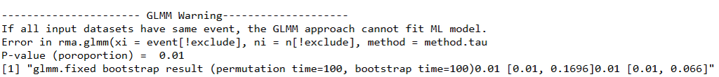

### 2.3.4 Example 3: Pathway Crosstalk Analysis

```r
## step 4, call PWcTalk function (4.1) or, alternatively, a code block (4.2)to perform pathway crosstalk analysis
#### NOTE: One must execute MetaGSCA_Multi_Geneset() on sufficiently many gene sets (say >100) before attempting step 4.
#### To enable swift testing of pathway cross talk analysis, we provide two existent example input files as if they were generated from step 3.2.
dir.create(file.path(workdir, 'PWcTalk'), showWarnings = FALSE)
setwd(file.path(workdir, "PWcTalk"))
## step 4.1, one code line to execute pathway crosstalk analysis. Simple, but no flexibility for layout tuning.
PWcTalk(infile=file.path(workdir,'PWcTalk/input2PWcTalk.real.csv'),test='binary',
  pTh.dataset=0.01,pTh.pwPair=0.01,pTh.pw=0.01,figname='PWcTalk',
  pdfW=10,pdfH=10,asp=0.7,vbase=15,ebase=2,vlbase=1,power=1/2)
## step 4.2, one code block to execute pathway crosstalk analysis. More code lines, but enabling interactive layout tuning.
infile <- file.path(workdir,'PWcTalk/input2PWcTalk.small.csv')
pTh.dataset=0.01
pTh.pwPair=0.01
pTh.pw=0.01
test='phi'
dichotGSAR.res <- dichotGSAR(infile,pTh.dataset=pTh.dataset)
PWsim.res <- PWsim(dichotGSAR.res$dichotP,test=test)
edges <- PWsimDichot(PWsim.res,dichotGSAR.res$metaP,pTh.pwPair=pTh.pwPair,pTh.pw=pTh.pw)
PWpair <- subset(edges,connect==1)[,1:3]
pws <- unique(as.character(unlist(PWpair[,1:2])))
PWp <- data.frame(pws,pwP=dichotGSAR.res$metaP[pws])
g_tkid <- PWcTalkNW(PWpair,PWp)
##### PAUSE: user can adjust the network layout on the pop-out graphic window identified with an integer of g_tkid$tkid.
coords <- tk_coords(g_tkid$tkid)
g_tkid <- PWcTalkNW(PWpair,PWp,layout=coords,pdfW=14,pdfH=10,figname='PWcTalk',asp=0.5)
```

# 3 Citing MetaGSCA